# Effects of Dexamethasone on NCD/HFD Mouse Quadriceps

Laura Gunder and Dave Bridges

January 8, 2018

# 1 Purpose

to examine the molecular effects of dexamethasone at varying lengths of treatment on obese and non-obese mice

# 2 Experimental Details

The relevant protocols used were:

- RNA Purification, a modified version of http://bridgeslab.sph.umich.edu/protocols/index.php?title=Preparation_of_RNA_Samples_from_Mouse_Tissues&oldid=1359
- cDNA Synthesis, used 2 ug then diluted cDNA 5X prior to qPCR: http://bridgeslab.sph.umich.edu/protocols/index.php?title=First_Strand_cDNA_Synthesis_(AB_Kit)&oldid=1242
- qPCR: http://bridgeslab.sph.umich.edu/protocols/index.php?title=QPCR&oldid=1252

# 3 Raw Data

The sample mapping is found in sample-key.csv and the qPCR data can be found in Well Results New.csv. This analysis can be found in /Users/davebrid/Documents/GitHub/CushingAcromegalyStudy/scripts/scripts-muscle and was most recently run on Thu Apr 4 09:29:53 2019.

We removed the samples 2625,2618,2636,2642 from the dataset because they did not amplify. We removed wells J1,J6,J7,J9,J11,J12,G7,D13,D16,A15,C24,C17,J10,B21 in the first experiment and P6,G5,G7,G4,G1,G2,G8,G3,J10,O21 in the second experiment because they were outliers relative to the other technical replicates.

# 4 Analysis

All mRNA levels were adjusted to **Pgk1**, then normalized to **NCD** at time **0**. Summarized data was written out to Analysed Control Gene Data.csv.

# 5 Foxo1 versus Foxo3a

Relative amplification of Foxo1 and Foxo3

| Target Name | Ct | DCt | Quant |
| --- | --- | --- | --- |
| Foxo1 | 24.4 | 0.00 | 1 |
| Foxo3 | 22.9 | -1.59 | 3 |

# 6 Plots of changes in gene expression

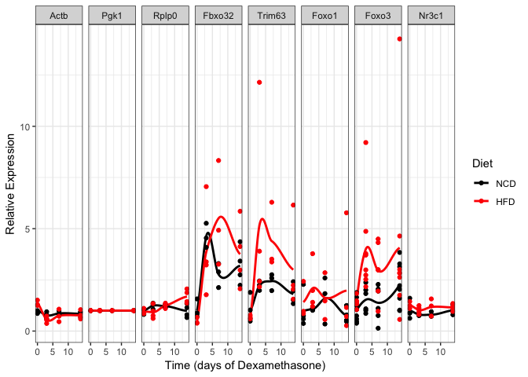

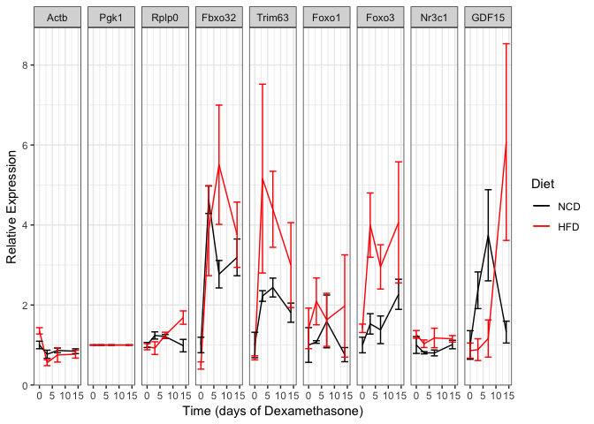

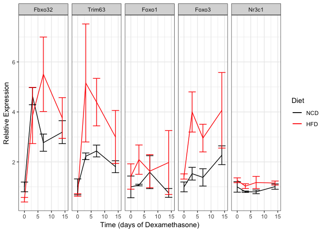

## 6.1 Statistics

### 6.1.1 Baseline Effects of Diet

First tested if there was an effect at baseline for expression of *Trim63* and *Fbxo32*.

Pairwise statistics for baseline effects of diet.

| Target Name | HFD.Effect | Shapiro.p | Levene.p | Wilcox.p | Welch.p | Student.p |
| --- | --- | --- | --- | --- | --- | --- |
| Fbxo32 | 0.487 | 0.115 | 0.549 | 0.057 | 0.073 | 0.088 |
| Trim63 | 0.678 | 0.348 | 0.168 | 0.857 | 0.388 | 0.434 |
| Foxo1 | 1.415 | 0.088 | 0.989 | 0.229 | 0.565 | 0.560 |
| Foxo3 | 1.417 | 0.464 | 0.058 | 0.142 | 0.089 | 0.115 |
| Nr3c1 | 1.264 | 0.279 | 0.516 | 0.400 | 0.315 | 0.359 |
| GDF15 | 0.860 | 0.002 | 0.690 | 0.662 | 0.737 | 0.760 |

### 6.1.2 Effects of Dexamethasone Over Time

First did pairwise tests at each time point.

Pairwise statistics for effects of diet in dexamethasone treated animals.

| Time | Target Name | HFD.Effect | Shapiro.p.HFD | Shaprio.p.NCD | Shapiro.p | Levene.p | Wilcox.p | Welch.p | Student.p |
| --- | --- | --- | --- | --- | --- | --- | --- | --- | --- |
| 3 | Fbxo32 | 0.833 | 0.336 | 0.758 | 0.336 | 0.396 | 0.400 | 0.551 | 0.595 |
| 3 | Trim63 | 2.319 | 0.043 | 0.860 | 0.043 | 0.312 | 0.400 | 0.302 | 0.342 |
| 3 | Foxo3 | 2.616 | 0.009 | 0.340 | 0.009 | 0.288 | 0.001 | 0.018 | 0.025 |
| 3 | Nr3c1 | 1.279 | 0.906 | 0.645 | 0.645 | 0.055 | 0.229 | 0.095 | 0.108 |
| 7 | Fbxo32 | 1.988 | 0.625 | 0.669 | 0.625 | 0.267 | 0.200 | 0.203 | 0.148 |
| 7 | Trim63 | 1.803 | 0.080 | 0.394 | 0.080 | 0.482 | 0.100 | 0.170 | 0.116 |
| 7 | Foxo3 | 2.139 | 0.634 | 0.486 | 0.486 | 0.474 | 0.065 | 0.041 | 0.037 |
| 7 | Nr3c1 | 1.467 | 0.804 | 0.137 | 0.137 | 0.275 | 0.400 | 0.261 | 0.215 |
| 14 | Fbxo32 | 1.177 | 0.880 | 0.883 | 0.880 | 0.302 | 0.886 | 0.573 | 0.568 |
| 14 | Trim63 | 1.658 | 0.041 | 0.726 | 0.041 | 0.423 | 0.343 | 0.347 | 0.316 |
| 14 | Foxo3 | 1.793 | 0.001 | 0.508 | 0.001 | 0.373 | 0.505 | 0.283 | 0.268 |
| 14 | Nr3c1 | 1.140 | 0.999 | 0.693 | 0.693 | 0.790 | 0.343 | 0.332 | 0.329 |

Also analysed this with a linear model with diet and time as covariates, allowing for an interaction.

Linear model for effects of time and diet on Fbxo32

| term | estimate | std.error | statistic | p.value |
| --- | --- | --- | --- | --- |
| (Intercept) | 2.224 | 0.776 | 2.865 | 0.009 |
| DietHFD | 0.217 | 1.119 | 0.194 | 0.848 |
| Time | 0.091 | 0.094 | 0.972 | 0.341 |
| DietHFD:Time | 0.069 | 0.135 | 0.513 | 0.613 |

Linear model for effects of time and diet on Trim63

| term | estimate | std.error | statistic | p.value |
| --- | --- | --- | --- | --- |
| (Intercept) | 1.550 | 0.926 | 1.675 | 0.107 |
| DietHFD | 1.583 | 1.336 | 1.185 | 0.248 |
| Time | 0.041 | 0.112 | 0.365 | 0.718 |
| DietHFD:Time | 0.004 | 0.161 | 0.024 | 0.981 |

Linear model for effects of time and diet on Nr3c1

| term | estimate | std.error | statistic | p.value |
| --- | --- | --- | --- | --- |
| (Intercept) | 0.895 | 0.101 | 8.862 | 0.000 |
| DietHFD | 0.258 | 0.146 | 1.774 | 0.089 |
| Time | 0.004 | 0.012 | 0.323 | 0.750 |
| DietHFD:Time | -0.005 | 0.018 | -0.282 | 0.781 |

Linear model for effects of time and diet on Foxo1

| term | estimate | std.error | statistic | p.value |
| --- | --- | --- | --- | --- |
| (Intercept) | 1.170 | 0.483 | 2.424 | 0.023 |
| DietHFD | 0.510 | 0.696 | 0.732 | 0.471 |
| Time | -0.016 | 0.058 | -0.270 | 0.790 |
| DietHFD:Time | 0.037 | 0.084 | 0.439 | 0.665 |

Linear model for effects of time and diet on Foxo3

| term | estimate | std.error | statistic | p.value |
| --- | --- | --- | --- | --- |
| (Intercept) | 1.045 | 0.565 | 1.848 | 0.070 |
| DietHFD | 1.415 | 0.815 | 1.735 | 0.089 |
| Time | 0.083 | 0.068 | 1.220 | 0.228 |
| DietHFD:Time | 0.039 | 0.098 | 0.401 | 0.690 |

# 7 Interpretation

None of these time courses have a significant interaction between time and diet